# R Notebook Basisc of Data Visualization with R

Irina Garanina

18.10.2024

```r
hogwarts <- read_csv("hogwarts_2024.csv")
hogwarts |> glimpse()
```

```
Rows: 560
Columns: 60
$ id                                   <dbl> 1, 2, 3, 4, 5, 6, 7, 8, 9, 10, 11, 12, 13, 14, 15, 16, 17,…
$ house                                <chr> "Ravenclaw", "Hufflepuff", "Ravenclaw", "Hufflepuff", "Huf…
$ course                               <dbl> 4, 5, 4, 2, 2, 6, 7, 5, 2, 3, 7, 5, 6, 2, 2, 7, 4, 4, 6, 7…
$ sex                                  <chr> "female", "male", "female", "male", "female", "male", "fem…
$ wandCore                             <chr> "unicorn hair", "phoenix feather", "dragon heartstring", "…
$ bloodStatus                          <chr> "half-blood", "half-blood", "half-blood", "half-blood", "h…
$ result                               <dbl> 94, 33, 137, 27, 67, 126, 63, 7, -84, 171, 2, 141, 150, 11…
$ `Defence against the dark arts exam` <dbl> 73, 38, 52, 50, 47, 44, 51, 47, 22, 57, 27, 57, 51, 58, 78…
$ `Flying exam`                        <dbl> 33, 36, 73, 42, 41, 52, 34, 34, 23, 79, 46, 50, 59, 38, 62…
$ `Astronomy exam`                     <dbl> 57, 45, 66, 49, 57, 59, 58, 37, 53, 54, 49, 68, 66, 64, 68…
$ `Herbology exam`                     <dbl> 73, 50, 62, 39, 38, 46, 59, 23, 27, 67, 44, 70, 39, 34, 50…
$ `Divinations exam`                   <dbl> 66, 54, 72, 42, 47, 49, 42, 38, 13, 56, 38, 57, 79, 62, 58…
$ `Charms exam`                        <dbl> 60, 70, 77, 46, 35, 55, 86, 20, 40, 67, 31, 61, 54, 57, 55…
```

[output cut: 47 more lines]

```r
# Changing some variables type to factors
hogwarts <- hogwarts |> mutate(
  across(c(house, course, sex, wandCore, bloodStatus), ~ as.factor(.x))
)
```

## Scatterplots, task 1

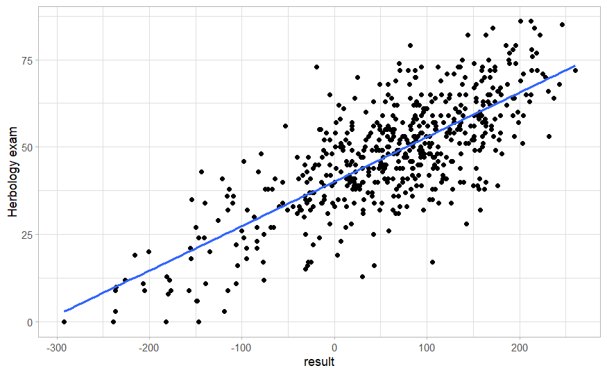

```r
#Scatterplots, task 1
hogwarts |>
  ggplot(aes(x = `result`,
                 y = `Herbology exam`))+
  geom_point()+
   geom_smooth(se = FALSE,
              method = "lm")  +
  theme_custom
```

#### Похоже, что есть сильная линейная зависимость между общими результатами студента и результатами экзамена по травологии

## Scatterplots, task 2

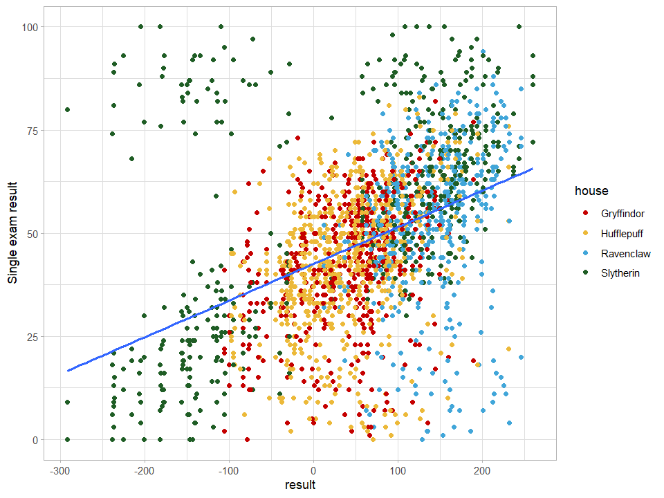

```r
hogwarts |> pivot_longer(cols = c(`Herbology exam`, `Muggle studies exam`, `Divinations exam`, `Potions exam`),
               names_to = "exam", values_to = "score") |>
 ggplot(aes(x = `result`, y = `score`)) +
  geom_point(aes(colour = house)) +
   geom_smooth(se = FALSE, method = "lm") +
   scale_colour_manual(values = c("Gryffindor" = "#C50000",
                             "Hufflepuff" = "#ECB939",
                             "Ravenclaw" = "#41A6D9",
                             "Slytherin" = "#1F5D25")) +
   labs( y = "Single exam result") +
  theme_custom
```

#### Зависимость с первого графика все еще сохранилась в целом для всех экзаменов, но ее нарушают ученики Слизерина, имеющие высокие оценки по какому-то предмету, независимо от общего тренда успеваемости

# Scatterplots, task 3

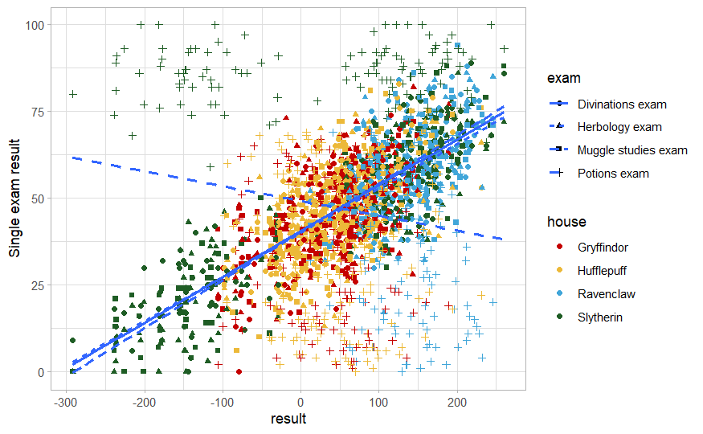

```r
hogwarts |> pivot_longer(cols = c(`Herbology exam`, `Muggle studies exam`, `Divinations exam`, `Potions exam`),
               names_to = "exam", values_to = "score") |>
 ggplot(aes(x = `result`, y = `score`)) +
  geom_point(aes(colour = house, shape = exam)) +
   geom_smooth(se = FALSE, method = "lm",aes(linetype = exam)) +
   scale_colour_manual(values = c("Gryffindor" = "#C50000",
                             "Hufflepuff" = "#ECB939",
                             "Ravenclaw" = "#41A6D9",
                             "Slytherin" = "#1F5D25")) +
   labs( y = "Single exam result") +
  theme_custom
```

# Geom_col, task 1

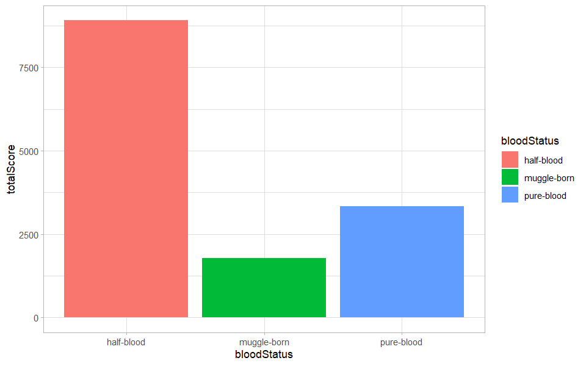

```r
hogwarts |>
  mutate(semesterScore = rowSums(across(21:37))) |>
  group_by(bloodStatus) |>
  summarise(totalScore = sum(semesterScore, na.rm = TRUE)) |> ggplot() +
  geom_col(aes(x = bloodStatus, y = totalScore, fill = bloodStatus)) +
  theme_custom
```

#### Версии почему результаты такие: 1. Разное количество учеников в каждой группе 2. Маглам сложнее учиться 3. Чистокровные относятся к более высокому и привелигированному классу, для которого учеба менее важна, чем для полукровок

# Geom_col, task 2

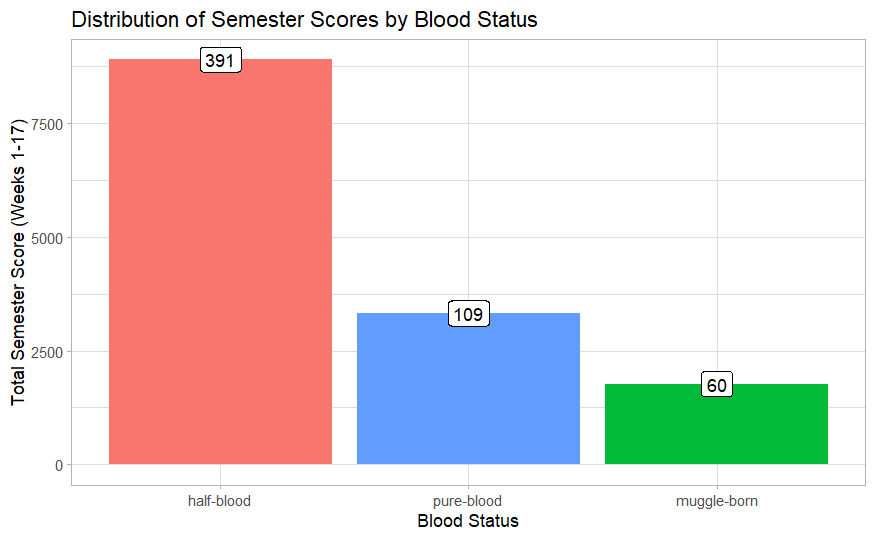

```r
hogwarts |>
  mutate(semesterScore = rowSums(across(21:37))) |>
  group_by(bloodStatus) |>
  summarise(totalScore = sum(semesterScore, na.rm = TRUE),
            studentCount = n()) |> ggplot() +
  geom_col(aes(x = fct_reorder(bloodStatus,totalScore,.desc = TRUE),
               y = totalScore, fill = bloodStatus)) +
  geom_label(aes(x = fct_reorder(bloodStatus,totalScore,.desc = TRUE), y = totalScore, label = studentCount)) +
  labs(title = "Distribution of Semester Scores by Blood Status",
       x = "Blood Status",
       y = "Total Semester Score (Weeks 1-17)") +
  theme_custom +
  theme(legend.position = "none")
```

#### Результат соответсвует моей первой гипотезе

# Geom_col, task 3

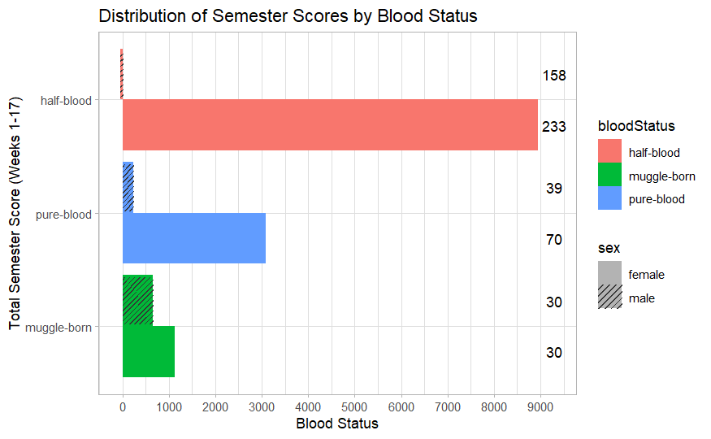

```r
DZ2 <- hogwarts |>
  mutate(semesterScore = rowSums(across(21:37))) |>
  group_by(bloodStatus, sex) |>
  summarise(totalScore = sum(semesterScore, na.rm = TRUE),
            studentCount = n()) |>
  ggplot(aes(y = fct_reorder(bloodStatus,totalScore),
               x = totalScore, fill = bloodStatus, group = sex))+
  geom_col(position = position_dodge(0.9)) +
  geom_text(aes(x = 9300, label = studentCount), position = position_dodge(0.9)) +
  geom_col_pattern(
    aes(pattern = sex),
    pattern_fill = "black",
    pattern_angle = 45,
    pattern_density = 0.1,
    pattern_spacing = 0.01,
    position = position_dodge2(preserve = 'single'),
  ) +
  #не нашла способа как отобразить пол в подписи к осям и как сделать раскраску баров попроще, этот вариант нагуглила
  scale_pattern_manual(
    values = c("none", "stripe"),
    guide = guide_legend(override.aes = list(fill = "grey70"))) +
  scale_fill_discrete(
    guide = guide_legend(override.aes = list(pattern = "none"))) +
  labs(title = "Distribution of Semester Scores by Blood Status",
       x = "Blood Status",
       y = "Total Semester Score (Weeks 1-17)") +
  scale_x_continuous(breaks = seq(0,9000,l=10)) +
  theme_custom +
  theme()
DZ2

ggsave("DZ2.png", DZ2, width = 8, height = 5, dpi = 300, units = "in")
```

# Geom_col, task 4

#### Coord_flip переворачивает график, это удобно когда все элементы имеют координаты в осях, если они имеют позицию заданную через направление это может не сработать.

# Other task 1

```r
hogwarts_long <- hogwarts |> pivot_longer(cols = c('Herbology exam', 'Study of ancient runes exam'), names_to = "group", values_to = "value")

density <- hogwarts_long |>
ggplot(aes(x = value, fill = group, color = group)) +
  geom_density(alpha = 0.4) +
  labs( x = "Value", y = "Density") +
  theme_custom

boxplot <- hogwarts_long |>
ggplot(aes(x=group, y=value)) +
    geom_boxplot(aes(fill=group), alpha=0.2) +
    scale_x_discrete(labels=c("Herbology","Ancient runes")) +
    xlab("Exam")+
    scale_fill_manual(labels=c("Herbology","Ancient runes"),
                    values = c("Herbology exam" = "lightblue", "Study of ancient runes exam" = "red", name="Exam"))+
  theme_custom

heat <- hogwarts |>
ggplot(aes(x=`Herbology exam`, y = `Study of ancient runes exam`)) +  geom_bin2d() + scale_fill_gradient(low = "lightblue", high = "red") +
  theme_custom +
  labs(x = "Herbology", y = "Ancient runes")
```

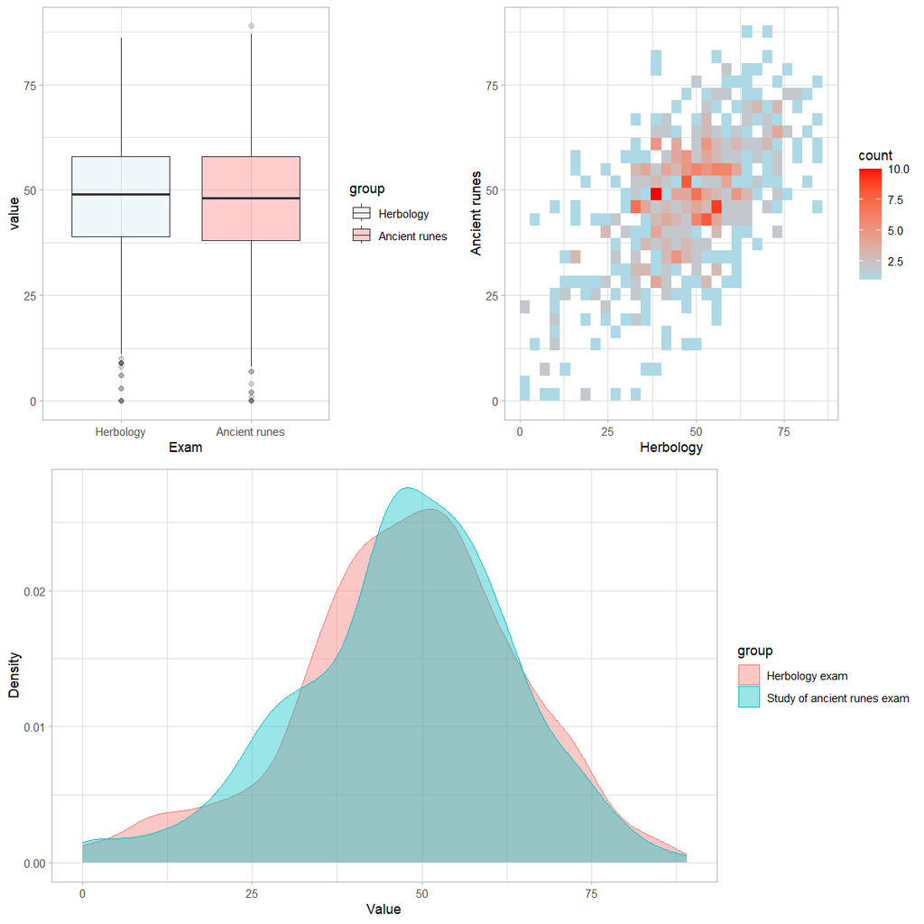

```r
grid.arrange(arrangeGrob(boxplot, heat, ncol = 2), density, nrow = 2)
```

# Other, task 2

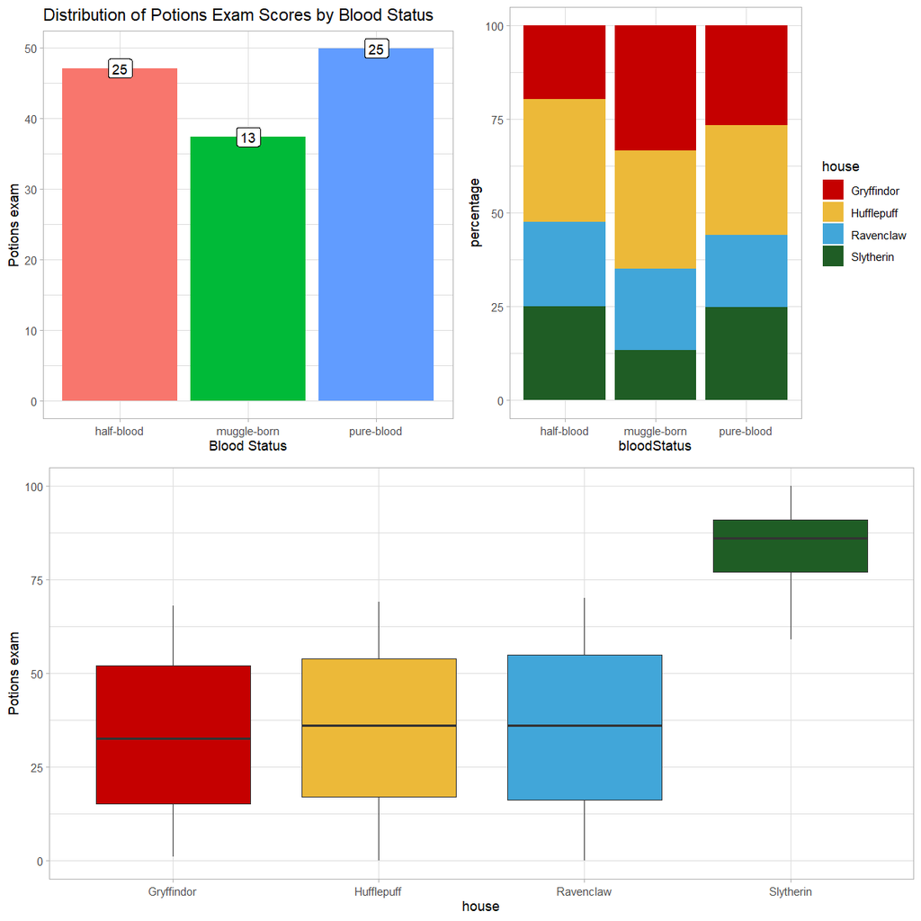

```r
mean_potions <- hogwarts |>
  group_by(bloodStatus) |>
  summarize( slytherinPercent = round(mean(house == "Slytherin") * 100),
         avgPotionGrade = mean(`Potions exam`, na.rm = TRUE)) |>
  ggplot() +
  geom_col(aes(x = bloodStatus, y = avgPotionGrade, fill = bloodStatus)) +
  geom_label(aes(x =bloodStatus, y = avgPotionGrade, label = slytherinPercent)) +
  labs(title = "Distribution of Potions Exam Scores by Blood Status",
       x = "Blood Status",
       y = "Potions exam") +
  theme_custom +
  theme(legend.position = "none")

houses<- hogwarts |>
  group_by(bloodStatus, house) |>
  summarise(studentCount = n()) |>
  group_by(bloodStatus) |>
  mutate(totalStudents = sum(studentCount),
  percentage = (studentCount / totalStudents) * 100) |>
  ungroup()|>
  ggplot( aes(x = bloodStatus, y = percentage, fill = house)) +
  geom_col() +
  scale_fill_manual(values = c("Gryffindor" = "#C50000",
                             "Hufflepuff" = "#ECB939",
                             "Ravenclaw" = "#41A6D9",
                             "Slytherin" = "#1F5D25")) +
  ylim(0, 100) + theme_custom
boxplot <- hogwarts |>
  ggplot(aes(x = house, y = `Potions exam`, fill = house)) +
  geom_boxplot() +
  scale_fill_manual(values =  c("Gryffindor" = "#C50000",
                             "Hufflepuff" = "#ECB939",
                             "Ravenclaw" = "#41A6D9",
                             "Slytherin" = "#1F5D25")) +
  theme_custom +
  theme(legend.position = "none")

ggarrange(ggarrange(mean_potions, houses, ncol = 2),
          ggarrange(boxplot),
          nrow = 2)
```

#### Основываясь на этом и предыдущих графиках мне показалось, что оценки по зельеварению ставятся выше ученикам Слизерина, я посчитала процент учеников Слизерина, который показан числом на верхнем графике. Чтобы убедиться на втором графике показала распределение учеников по факультетам разного происхождения. У меня появилась еще идея, что возможно дело еще в учениках Гриффиндора, которым могут занижать оценку по этому предмету, поэтому построила третий график. Из него понятно, что дело вероятнее всего в учениках из Слизерина, в Гриффиндоре тоже есть небольшое снижение по сравнению с остальными, но не похоже на статистически значимое.

# Воспроизведение графика

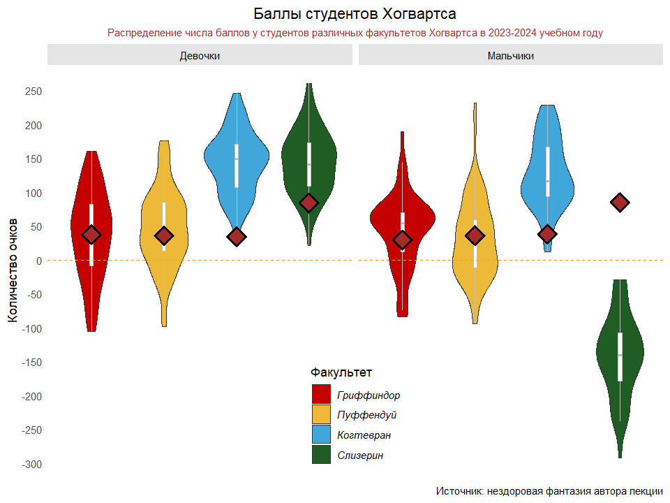

```r
sex_labels <- c("male" = "Мальчики", "female" = "Девочки")

hogwarts |> ggplot(aes(x = house, y = result, fill = house)) +
  geom_violin(trim = TRUE) +  # Violin plot без обрезки
  facet_grid(. ~ sex, labeller = labeller(sex = sex_labels)) +     # Фасет по полу в один ряд
  geom_boxplot(width = 0.05, fill = "white", color = "gray", outlier.shape = NA) +  # Боксплот внутри
  stat_summary(aes(y = `Potions exam`), fun = mean, geom = "point", shape = 23, size = 5, color ='black', fill = "brown", stroke = 1.5) +  # среднее ромбом
  theme_minimal() +
  labs(
    title = "Баллы студентов Хогвартса",
    subtitle = "Распределение числа баллов у студентов различных факультетов Хогвартса в 2023-2024 учебном году",
    caption = "Источник: нездоровая фантазия автора лекции",
    y = 'Количество очков'
  ) +
  theme(
    strip.background = element_rect(fill = "gray90", color = NA),  # Серый фон заголовков фасетов
    strip.text = element_text(color = "black"),  # Чёрный текст заголовков фасетов
    panel.grid = element_blank(),  # Убираем сетку с фона
    panel.background = element_rect(fill = "white", color = NA),  # Белый фон
    legend.position = c(0.5, 0.15),  # Легенда внизу
    legend.justification = "center",  # Центрируем легенду
    legend.direction = "vertical",  # Легенда в столбик
    legend.box = "vertical",  # Легенда в вертикальном формате
    legend.text = element_text(face = "italic"),
    plot.caption = element_text(hjust = 1),  # Сноска справа
    plot.title = element_text(hjust = 0.5),  # Центрирование заголовка
    axis.text.x = element_blank(),#убираем подписи на оси X
    axis.title.x = element_blank(),  # Убираем название оси X
    plot.subtitle = element_text(size = 9, color = "brown", hjust = 0.5),  # Центрирование и коричневый цвет сабтайтла
  ) +
  scale_y_continuous(breaks = seq(-300, 250, by = 50)) +
  geom_hline(yintercept = 0, color = "orange", linetype = "dashed") +  # Пунктирная линия на уровне 0
  scale_fill_manual(values = c("Gryffindor" = "#C50000",
                             "Hufflepuff" = "#ECB939",
                             "Ravenclaw" = "#41A6D9",
                             "Slytherin" = "#1F5D25"), name = 'Факультет',
                              labels=c("Гриффиндор","Пуффендуй", "Когтевран", "Слизерин"))
```

```r
NA
```